# Data Visualisation with `ggplot2`

- Show All Code
- Hide All Code
- View Source

Communicating your data

Author

Affiliation

Daniela Palleschi

Humboldt-Universität zu Berlin

Published

April 13, 2023

```r
knitr::opts_chunk$set(eval = T, # evaluate chunks
                      echo = T, # 'print code chunk?'
                      message = F, # 'print messages (e.g., warnings)?'
                      error = F, # stop when error encountered
                      warning = F) # don't print warnings
```

```r
## play sound if error encountered
### from: https://sejohnston.com/2015/02/24/make-r-beep-when-r-markdown-finishes-or-when-it-fails/
options(error = function(){    # Beep on error
  beepr::beep(sound = "wilhelm")
  Sys.sleep(2) #
  }
 )
## and when knitting is complete
.Last <- function() {          # Beep on exiting session
  beepr::beep(sound = "ping")
  Sys.sleep(6) # allow to play for 6 seconds
  }
```

```r
# Create references.json file based on the citations in this script
# make sure you have 'bibliography: references.json' in the YAML
rbbt::bbt_update_bib("_data_viz.qmd")
```

# 1 Data communication

## 1.1 Load packages and data

```r
# load tidyverse
library(tidyverse)

# load data
df_lifetime <- readr::read_csv(here::here("data/tidy_data_lifetime_pilot.csv"),
                               # for special characters
                               locale = readr::locale(encoding = "latin1")
                               ) |>
  mutate_if(is.character,as.factor) |> # all character variables as factor
  filter(type == "critical", # only critical trials
         px != "px3") # this participant had lots of 0's for some reason
```

## 1.2 Tables

- we can create summaries of our data

```r
# compute summary
summary_ff <- df_lifetime |>
  filter(region=="verb") |>
  group_by(condition,lifetime,tense) %>%
  summarise(N = n(),
            mean.ff = mean(ff, na.rm = T),
            sd = sd(ff, na.rm = T)) %>%
  # compute standard error, confidence intervals, and lower/upper ci bounds
  mutate(se = sd / sqrt(N),
         ci = qt(1 - (0.05 / 2), N - 1) * se,
         lower.ci = mean.ff - qt(1 - (0.05 / 2), N - 1) * se,
         upper.ci = mean.ff + qt(1 - (0.05 / 2), N - 1) * se)
```

- and print the output with the `kable()` function from the `knitr` package
  - for extra customisation you can also use the `kableExtra` package (e.g., with the `kable_styling()` function)

```r
# install.packages("knitr") # if not yet installed
knitr::kable(summary_ff, digits=1,
             caption = "Table with summmary statistics for first-fixation duration at the verb region")
```

Table with summmary statistics for first-fixation duration at the verb region

| condition | lifetime | tense | N | mean.ff | sd | se | ci | lower.ci | upper.ci |
| --- | --- | --- | --- | --- | --- | --- | --- | --- | --- |
| deadPP | dead | PP | 140 | 198.9 | 57.9 | 4.9 | 9.7 | 189.2 | 208.6 |
| deadSF | dead | SF | 139 | 194.6 | 67.9 | 5.8 | 11.4 | 183.2 | 205.9 |
| livingPP | living | PP | 140 | 194.2 | 77.3 | 6.5 | 12.9 | 181.3 | 207.1 |
| livingSF | living | SF | 140 | 186.0 | 57.6 | 4.9 | 9.6 | 176.4 | 195.6 |

### 1.2.1 Exercise

1. install the `knitr` package (`install.packages("knitr")`)
2. create an object with some summary statistics of the variable `rt`
- call it `summary_rt`
3. use `kable()` from `knitr` to print a table

```r
knitr::kable(summary_rt, digits=1,
             caption = "Summary of reaction times (ms) per condition")
```

Summary of reaction times (ms) per condition

| lifetime | tense | condition | N | mean.rt | sd |
| --- | --- | --- | --- | --- | --- |
| dead | PP | deadPP | 140 | 3530.5 | 2915.8 |
| dead | SF | deadSF | 139 | 1747.0 | 1153.4 |
| living | PP | livingPP | 140 | 2257.7 | 1346.3 |
| living | SF | livingSF | 140 | 2578.1 | 1958.7 |

# 2 Plotting reading times

- reading times are (usually) continuous variables
  - as are e.g., reaction times
- they are truncated at 0, meaning they cannot have negative values
  - because of this, they tend to have a *skewed distribution*

# 3 Plots with `ggplot2`

- `ggplot2` is part of the tidyverse (like `dplyr`)
  - uses a *layered grammar of graphics*
  - i.e., we build layers

# 4 An example: histogram

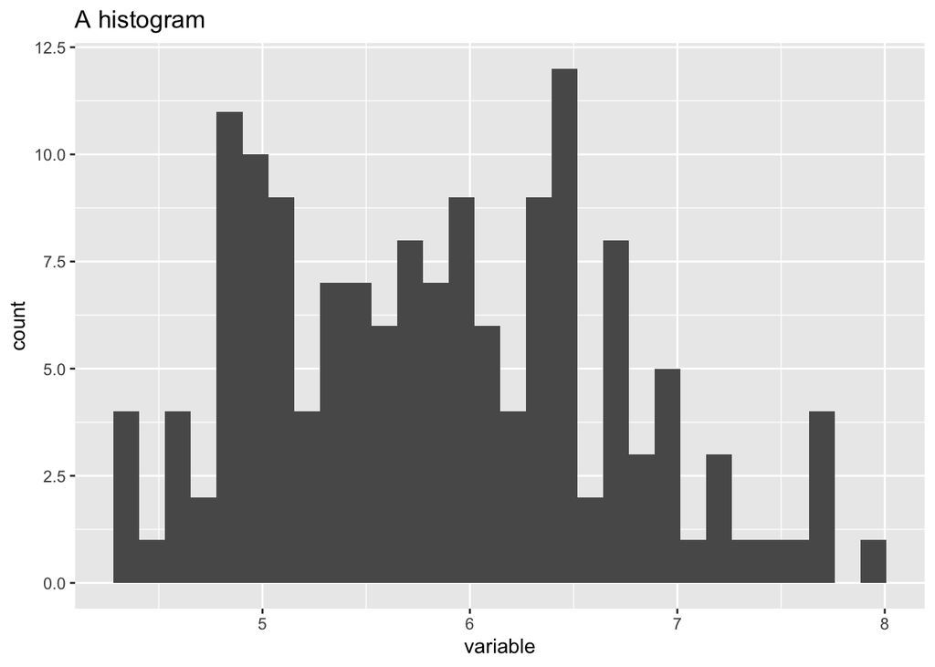

```r
iris |>
  ggplot(aes(x=Sepal.Length)) +
  geom_histogram() +
  labs(title = "A histogram",
       x = "variable")
```

## 4.1 Start layering

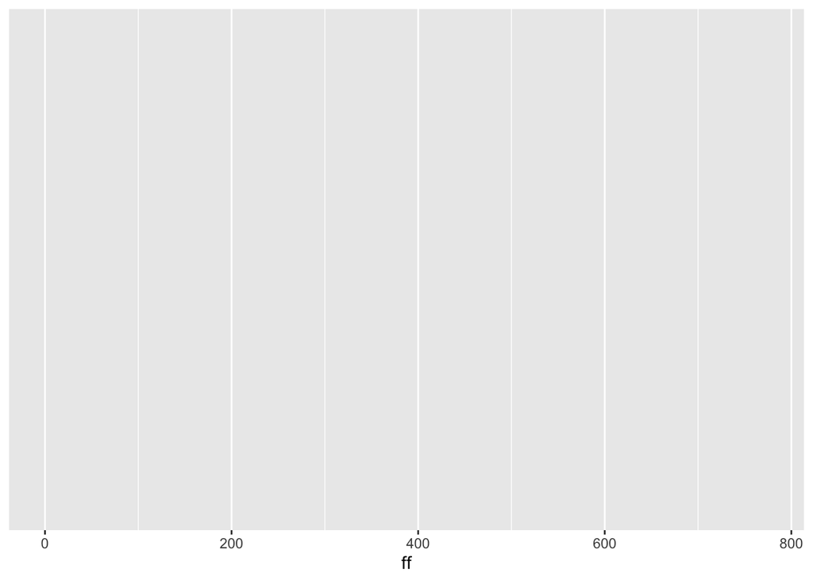

```r
df_lifetime |> ggplot(aes(ff)) # aes = 'aesthetic'
```

## 4.2 Add labels

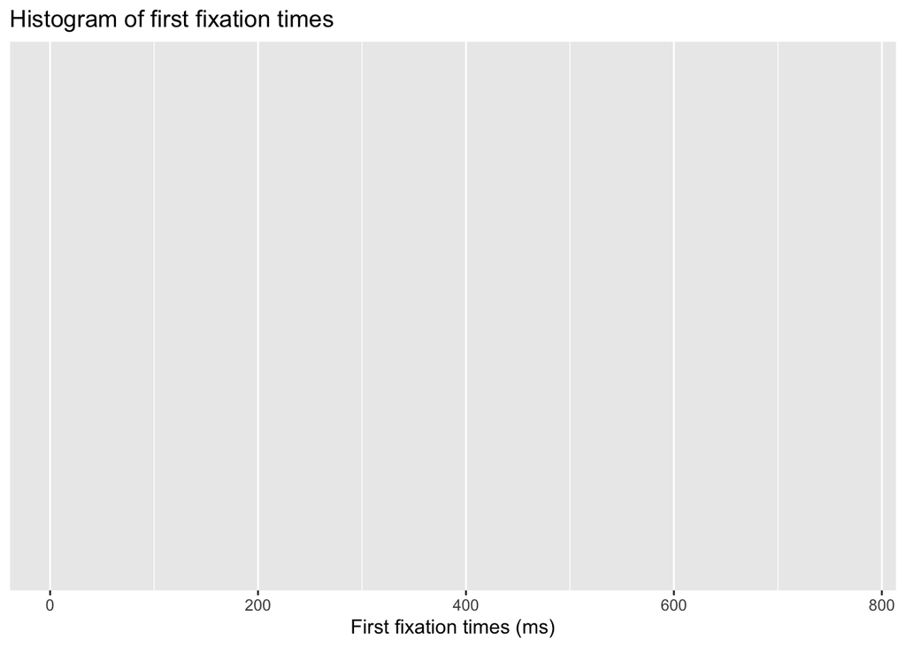

```r
df_lifetime |> ggplot(aes(ff)) +
  labs(title = "Histogram of first fixation times",
       x = "First fixation times (ms)")
```

## 4.3 Add

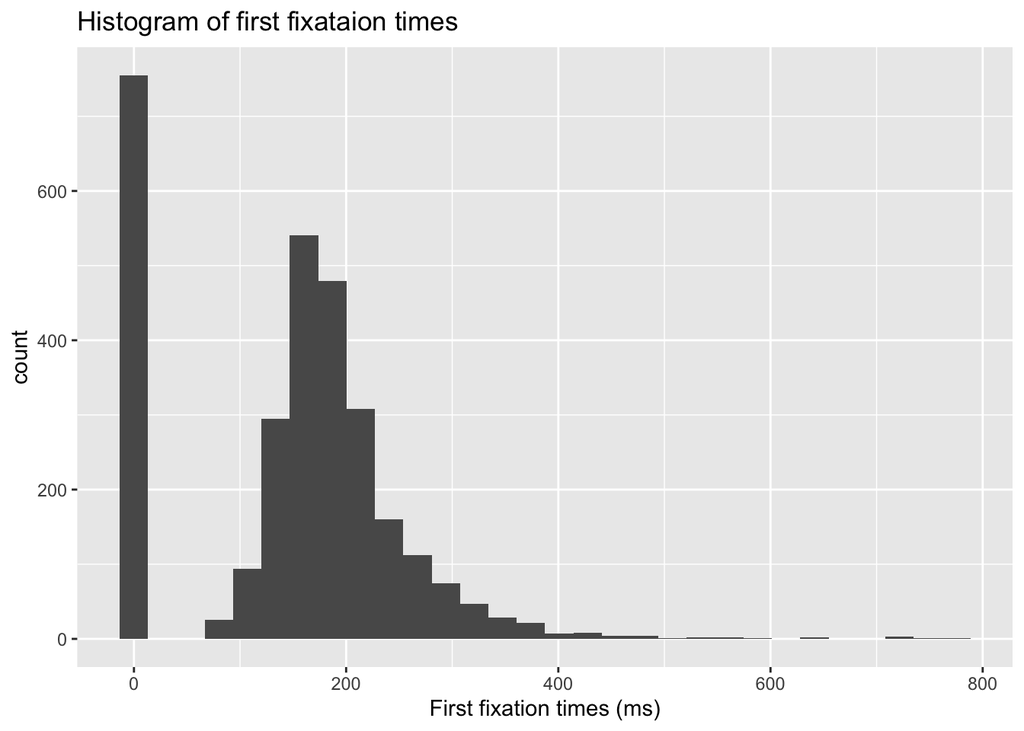

```r
df_lifetime |> ggplot(aes(ff)) +
  labs(title = "Histogram of first fixataion times",
       x = "First fixation times (ms)") +
  geom_histogram()
```

## 4.4 Add condition

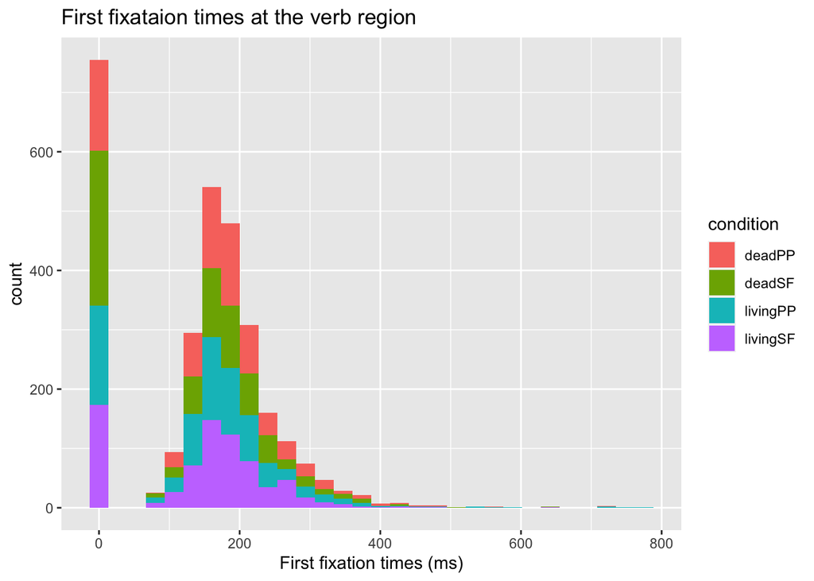

```r
df_lifetime |> ggplot(aes(ff, fill = condition)) +
  labs(title = "First fixataion times at the verb region",
       x = "First fixation times (ms)") +
  geom_histogram()
```

The colour here is STACKED!! i.e., not layered. Notice the distribution doesn’t change from all grey to coloured

## 4.5 Customisation

- we can add arguments to our geoms
  - e.g., transparency: `alpha =` takes a value between 0 to 1
- we can use `theme()` to customise font sizes, legend placement, etc.
- tehre are also popular preset themes, such as `theme_bw()` and `theme_minimal()`

**theme_bw()**

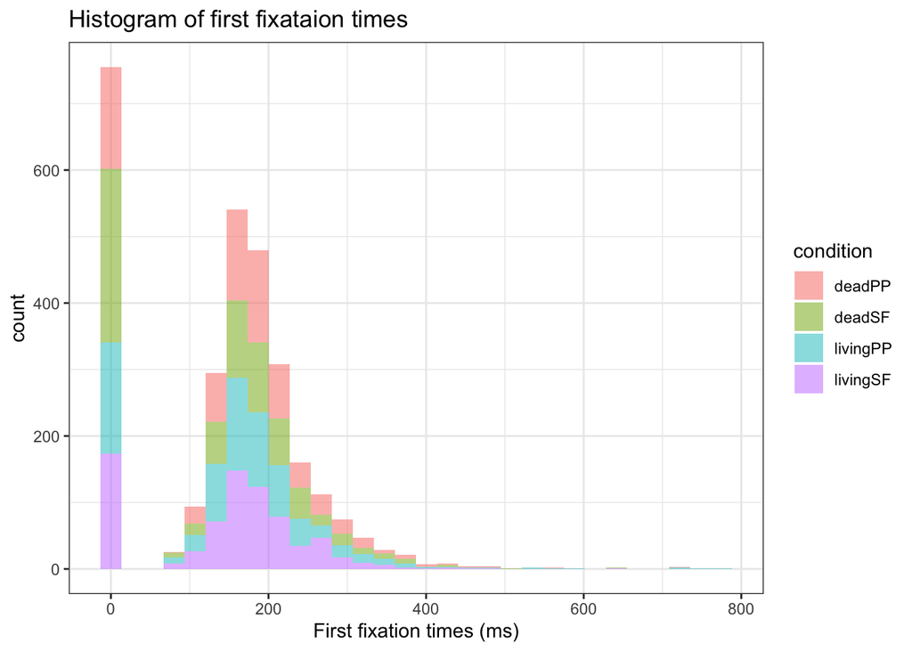

```r
df_lifetime |> ggplot(aes(ff, fill = condition)) +
  labs(title = "Histogram of first fixataion times",
       x = "First fixation times (ms)") +
  geom_histogram(alpha=.5) +
  theme_bw()
```

**theme_minimal()**

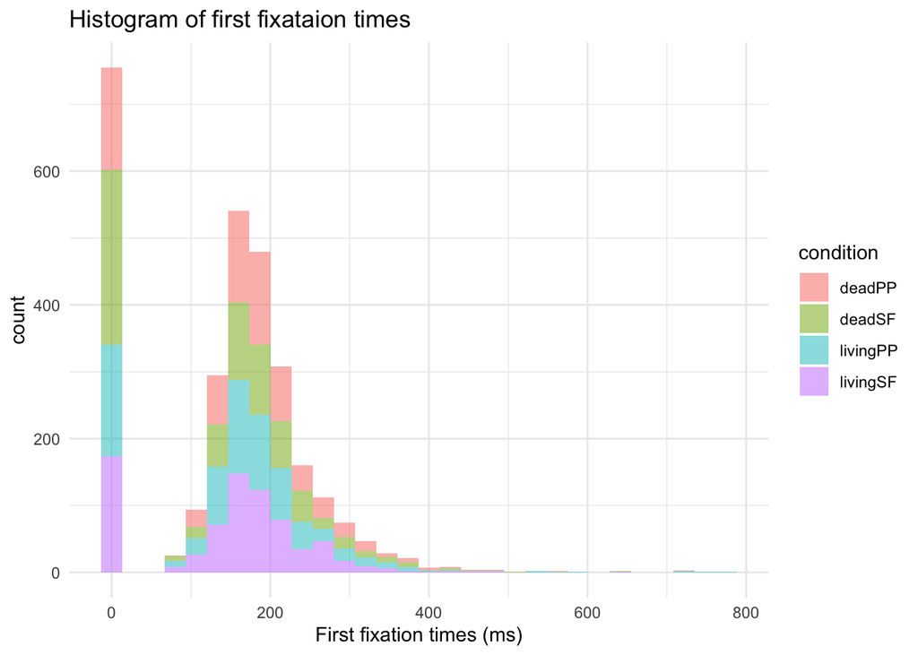

```r
df_lifetime |> ggplot(aes(ff, fill = condition)) +
  labs(title = "Histogram of first fixataion times",
       x = "First fixation times (ms)") +
  geom_histogram(alpha=.5) +
  theme_minimal()
```

# 5 Distributions

- show the distribution of observations
  - so we can see where the data are clustered
  - and eyeball the shape of the distribution
- we already saw the histogram, which shows the number of observations per variable value
- **density plots** are another useful plot for visualising distributions

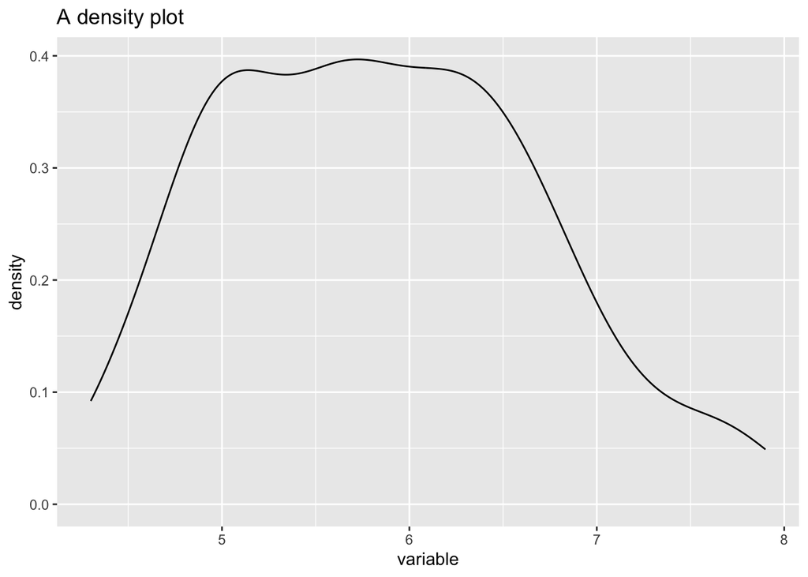

```r
iris |>
  ggplot(aes(x=Sepal.Length)) +
  geom_density() +
  labs(title = "A density plot",
       x = "variable")
```

## 5.1 Density plots

- below I just replaced `geom_histogram()` with `geom_density()`
  - I also filtered the data to include only values of `ff` above 0
- what is plotted along the y-axis? how does this differ from a histogram?

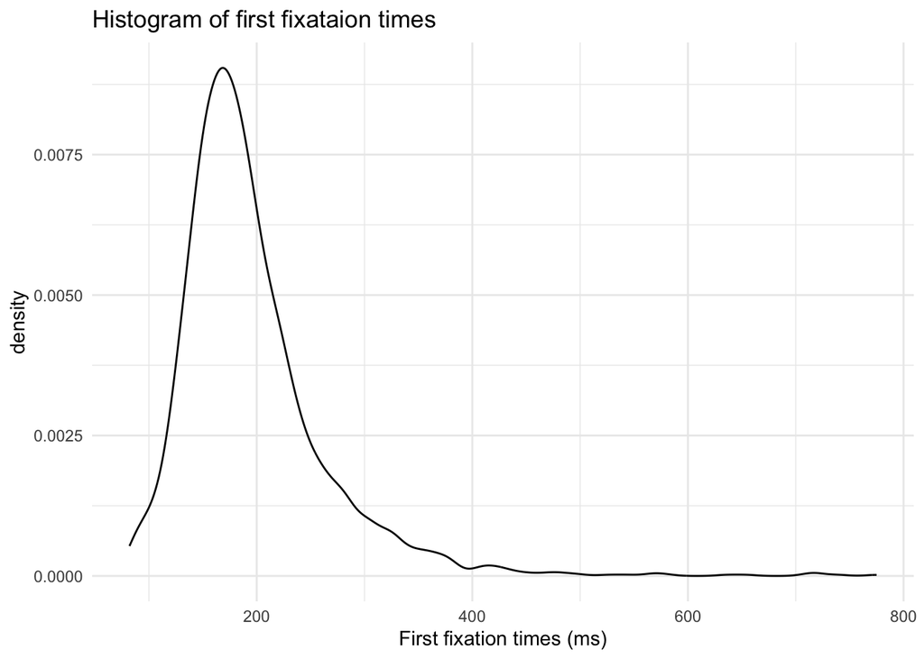

```r
df_lifetime |>
  filter(ff > 0) |>
  ggplot(aes(ff)) +
  labs(title = "Histogram of first fixataion times",
       x = "First fixation times (ms)") +
  geom_density() +
  theme_minimal()
```

## 5.2 Grouped density plots

- just like with histograms, we can look at the density plots of different subsets of the data with `aes(fill = )`
  - like region

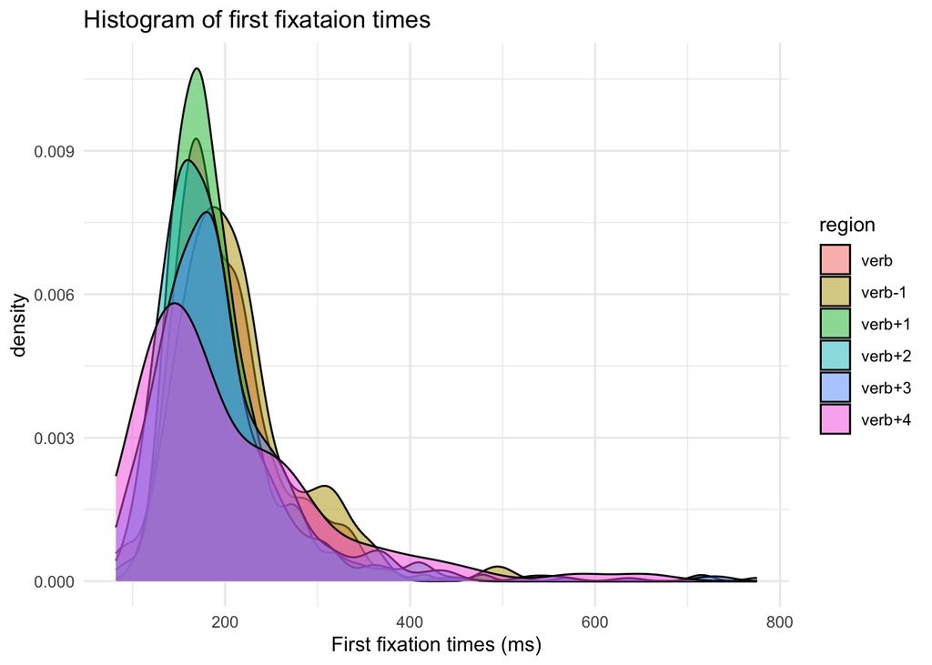

```r
df_lifetime |>
  filter(ff > 0) |>
  ggplot(aes(ff, fill = region)) +
  labs(title = "Histogram of first fixataion times",
       x = "First fixation times (ms)") +
  geom_density(alpha=.5) +
  theme_minimal()
```

### 5.2.1 `facet_grid()`

- there are a lot of overlapping density curves, let’s try to separate them with `facet_grid(x~y)`

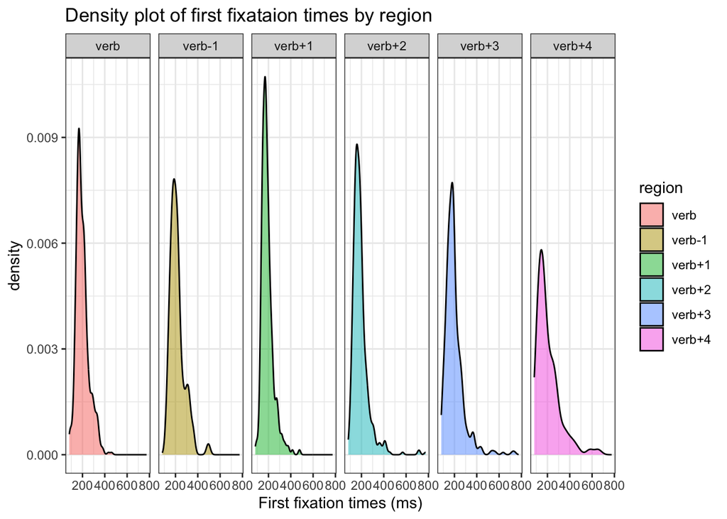

```r
df_lifetime |>
  filter(ff > 0) |>
  ggplot(aes(ff, fill = region)) +
  facet_grid(.~region) +
  labs(title = "Density plot of first fixataion times by region",
       x = "First fixation times (ms)") +
  geom_density(alpha=.5) +
  theme_bw()
```

- how would you describe the density plots of the different regions?

### 5.2.2 re-ordering factors

- by default, factors will be ordered alphabetically
  - but we don’t always want that
  - here, `verb-1` should be before `verb`

```r
df_lifetime <- df_lifetime %>%
  mutate(region = factor(region,
                         levels = c("verb-1","verb","verb+1","verb+2","verb+3","verb+4")))

summary(df_lifetime$region)
```

```
verb-1   verb verb+1 verb+2 verb+3 verb+4
   559    559    559    559    559    182
```

#### 5.2.2.1 Exercise

1. create a density plot with the fill colour set to `condition`, but:
- subset the data to only include the verb region
- you can decide if you want to use facets or to have the density curves overlayed
- your plot should look something like A or B:

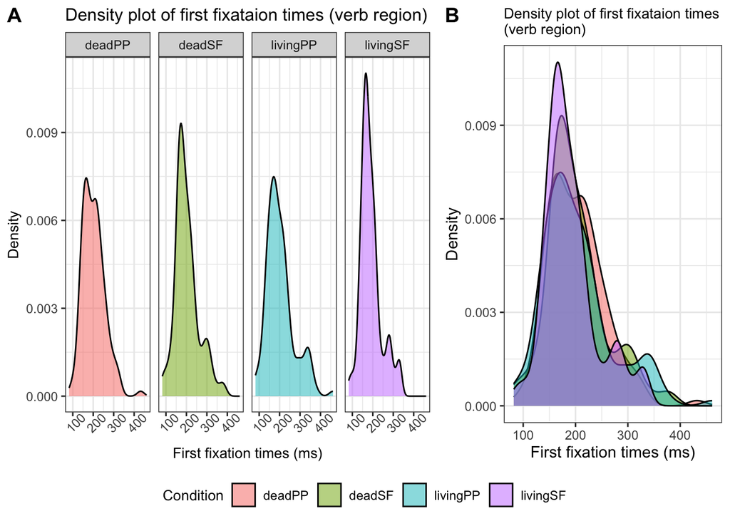

#### 5.2.2.2 Extra exercise

2. Can you produce these plots?

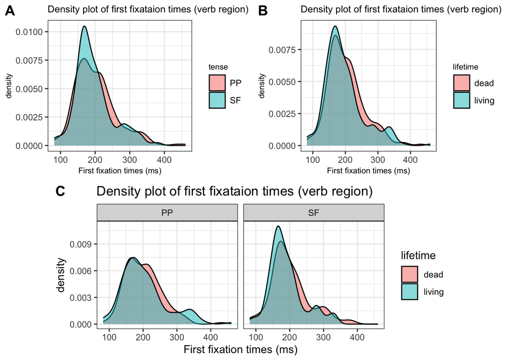

## 5.3 Scatterplots

- histograms and density plots plot a **single variable** along the x-axis
  - in most other plots the dependent (measure) variable is plotted along the y-axis by convention
- scatterplots plot the relationship between **two variables**

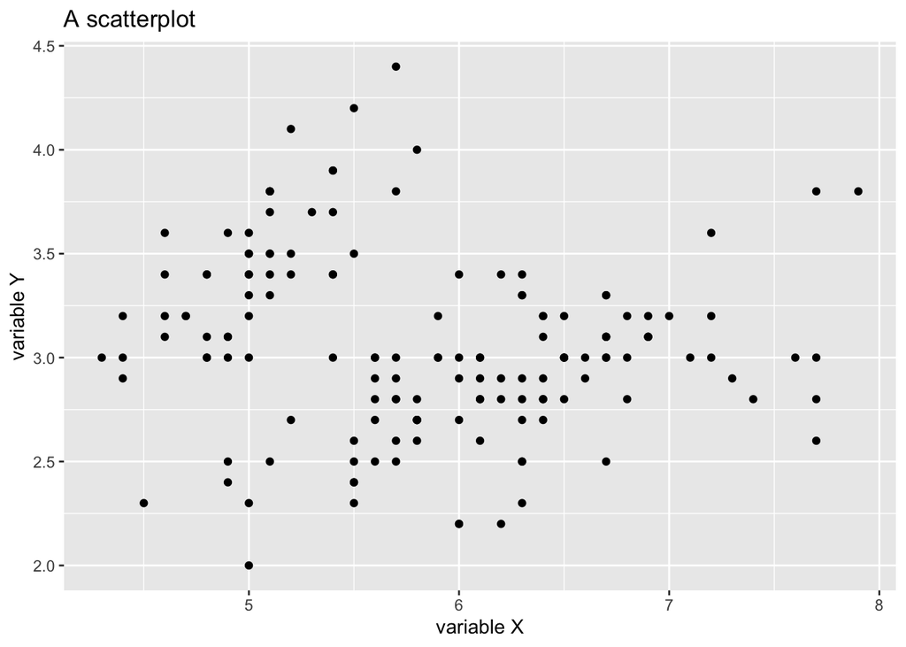

```r
iris |>
  ggplot(aes(x=Sepal.Length, y=Sepal.Width)) +
  geom_point() +
  labs(title = "A scatterplot",
       x = "variable X",
       y = "variable Y")
```

### 5.3.1 Scatterplots

- the figure below plots total reading times (verb region) to the verb region (x-axis) and reaction times to the critical sentence (y-axis)
  - what does each point represent?
  - how would you describe the relationship between the two variables?

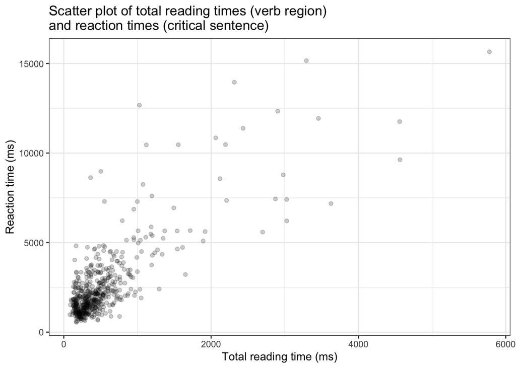

```r
df_lifetime |>
  filter(ff > 0,
         region == "verb") |>
  ggplot(aes(x = tt, y = rt)) +
  labs(title = "Scatter plot of total reading times (verb region)
and reaction times (critical sentence)",
       x = "Total reading time (ms)",
       y = "Reaction time (ms)") +
  geom_point(alpha = .2) +
  theme_bw()
```

#### 5.3.1.1 Exercise

1. Generate a scatterplot of total reading times and reaction times, with:
   - colour and shape set to condition
   - tip: these both belong in `aes()`
2. What information does this plot suggest?

# 6 Summary statistics

- measures of location: mean, median, mode
- measures of spread: (interquartile) range, standard deviation

## 6.1 Boxplots

- boxplots provide information about the distribution of a *continuous* variable
  - but includes information like *median* (dark line) and *quartiles* (box and whiskers)
  - and *outliers* (dots)
- like scatterplots, require x and y variables
  - but one of them needs to be **categorical**

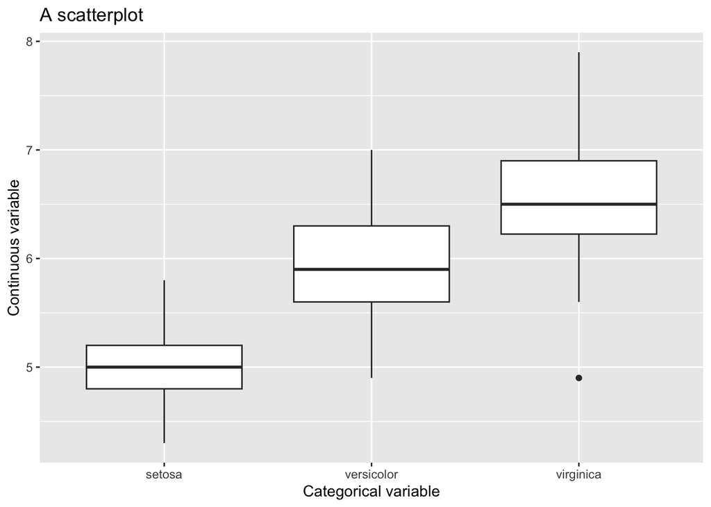

```r
iris |>
  ggplot(aes(x = Species, y = Sepal.Length)) +
  labs(title = "A scatterplot",
       x = "Categorical variable",
       y = "Continuous variable") +
  geom_boxplot()
```

## 6.2 Boxplot explained

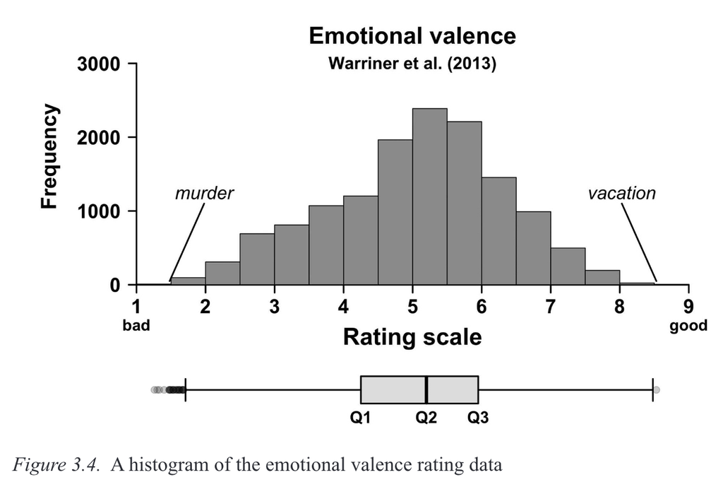

## 6.3 Boxplots

- let’s change our scatterplot to a boxplot

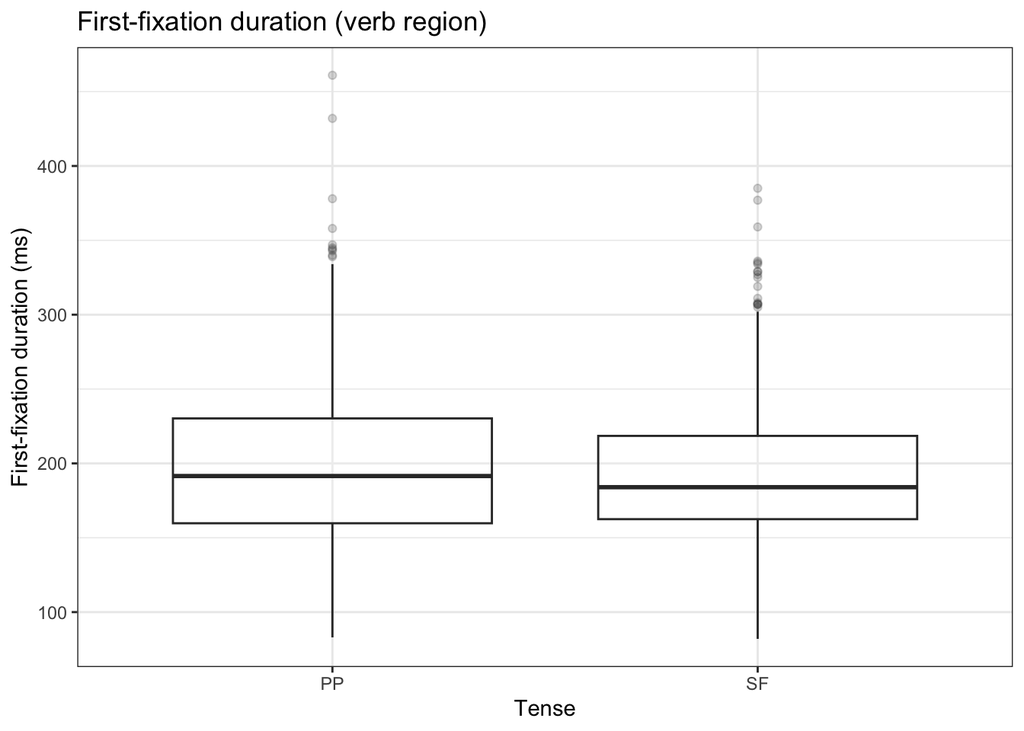

```r
df_lifetime |>
  filter(ff > 0,
         region == "verb") |>
  ggplot(aes(x = tense, y = ff)) +
  labs(title = "First-fixation duration (verb region)",
       x = "Tense",
       y = "First-fixation duration (ms)") +
  geom_boxplot(alpha = .2) +
  theme_bw()
```

### 6.3.1 Grouped boxplots

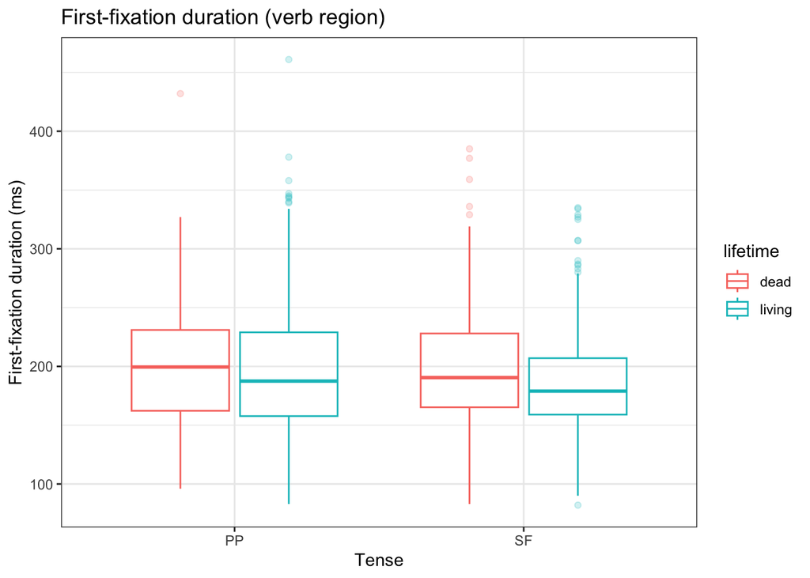

```r
df_lifetime |>
  filter(ff > 0,
         region == "verb") |>
  ggplot(aes(x = tense, y = ff, colour = lifetime)) +
  labs(title = "First-fixation duration (verb region)",
       x = "Tense",
       y = "First-fixation duration (ms)") +
  geom_boxplot(alpha = .2) +
  theme_bw()
```

#### 6.3.1.1 Exercise

1. Create a group boxplot (x = tense, fill = lifetime) for
- first-pass reading time (verb region)
- regression path duration (verb region)
- total reading time (verb region)
- reaction times (use the `distinct()` verb to have a single observation per participant and per trial)

## 6.4 Violin plots

## 6.5 Violin boxplots

# 7 Summary statistics

## 7.1 Interaction plots

- common for **factorial** designs, i.e., comparing *categorical* predictors
- there are 2 ways of producing them:
  - with your data frame and `stat_summary()`
  - or with a summary table and ggplot geoms `geom_point()`, `geom_errorbar()`, and `geom_line()`
- we’ll need our summary table to plot an interaction plot

| condition | lifetime | tense | N | mean.ff | sd | se | ci | lower.ci | upper.ci |
| --- | --- | --- | --- | --- | --- | --- | --- | --- | --- |
| deadPP | dead | PP | 140 | 198.9 | 57.9 | 4.9 | 9.7 | 189.2 | 208.6 |
| deadSF | dead | SF | 139 | 194.6 | 67.9 | 5.8 | 11.4 | 183.2 | 205.9 |
| livingPP | living | PP | 140 | 194.2 | 77.3 | 6.5 | 12.9 | 181.3 | 207.1 |
| livingSF | living | SF | 140 | 186.0 | 57.6 | 4.9 | 9.6 | 176.4 | 195.6 |

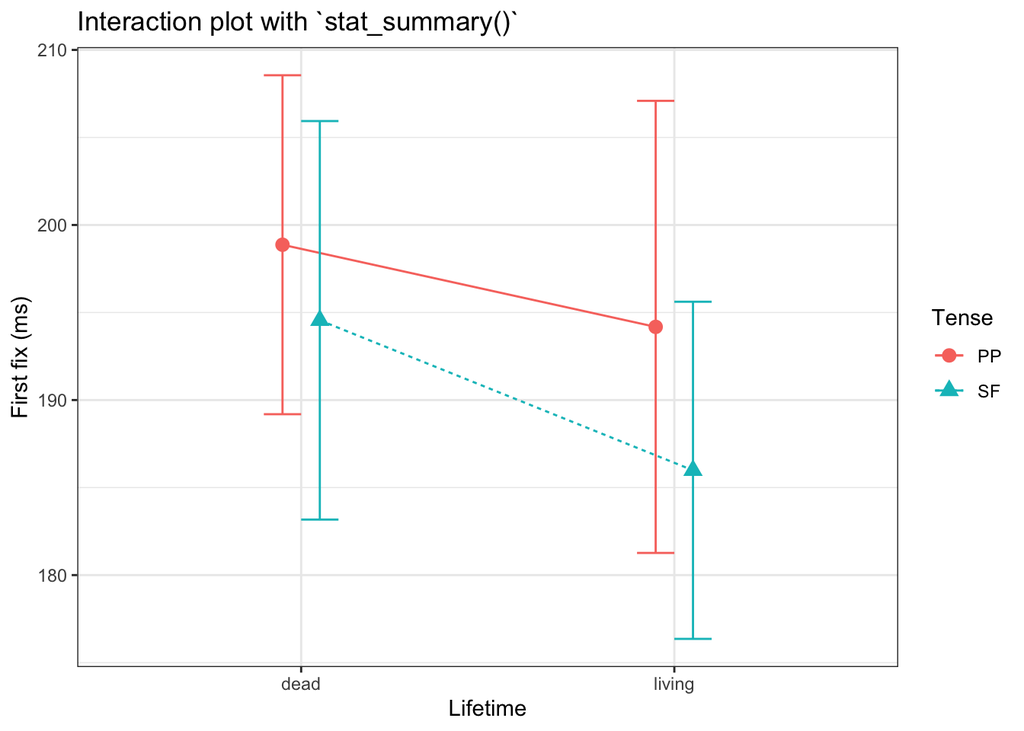

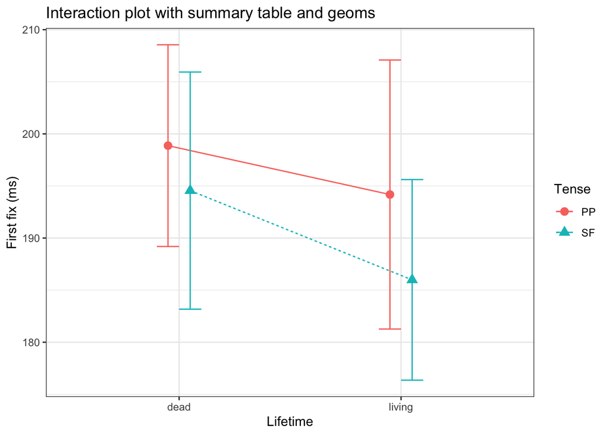

# 8 Binomial data

- binomial data are those with 2 categories, for example
  - present, absent
  - yes, no
- in our dataset, each trial ended with a binary naturalness judgement task
  - how might we plot such data?

## 8.1 Bar plot

- be sure to read in `accept` as a factor!

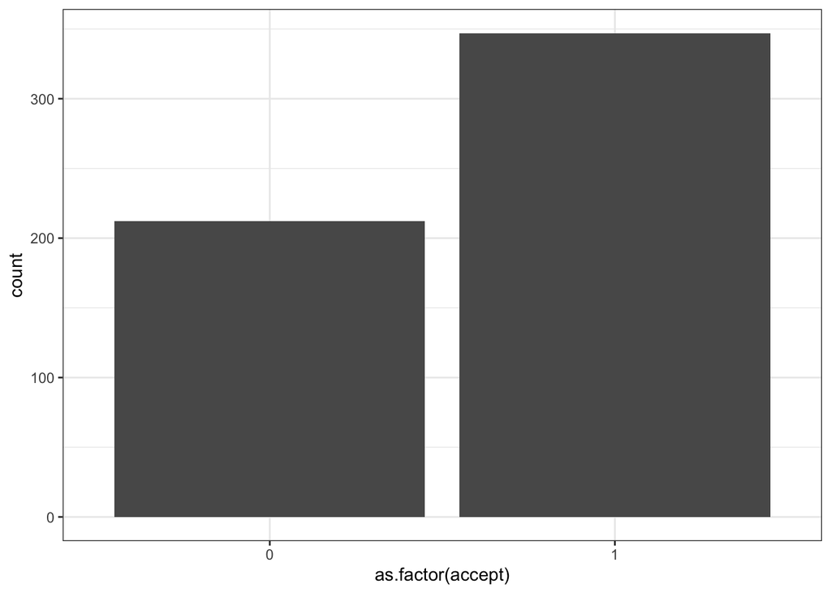

```r
df_lifetime |>
  distinct(px,trial,.keep_all=T) |>
  ggplot(aes(x = as.factor(accept) )) +
  geom_bar() +
  theme_bw()
```

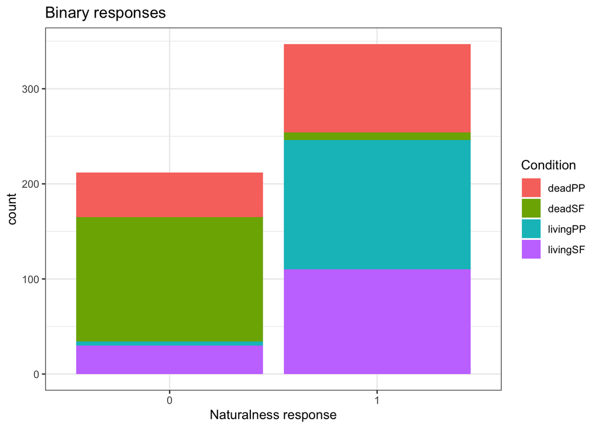

```r
df_lifetime |>
  distinct(px,trial,.keep_all=T) |>
  ggplot(aes(x = as.factor(accept), fill = condition)) +
  labs(title = "Binary responses",
       x = "Naturalness response",
       fill = "Condition") +
  geom_bar() +
  theme_bw()
```

## 8.2 Grouped bar plots

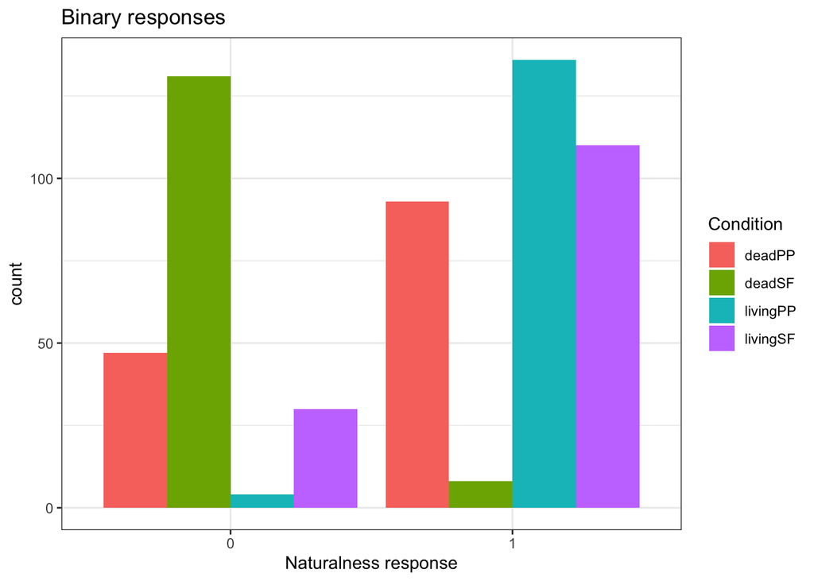

```r
df_lifetime |>
  distinct(px,trial,.keep_all=T) |>
  ggplot(aes(x = as.factor(accept), fill = condition)) +
  labs(title = "Binary responses",
       x = "Naturalness response",
       fill = "Condition") +
  geom_bar(position = "dodge") +
  theme_bw()
```

### 8.2.1 Exercise

1. Generate a grouped bar plot (i.e., `dodge`) with:
   - a facet grid for `tense`
   - plots `lifetime` on the x-axis
   - and fills the bars based on `accept`
   - change the labels accordingly
   - customise as you like

```r
df_lifetime |>
  distinct(px,trial,.keep_all=T) |>
  ggplot(aes(x = lifetime, fill = as.factor(accept))) +
  facet_grid(.~tense) +
  labs(title = "Binary responses",
       x = "Lifetime",
       fill = "Response") +
  geom_bar(position = "dodge") +
  theme_bw()
```

## 8.3 Grouped bar plots

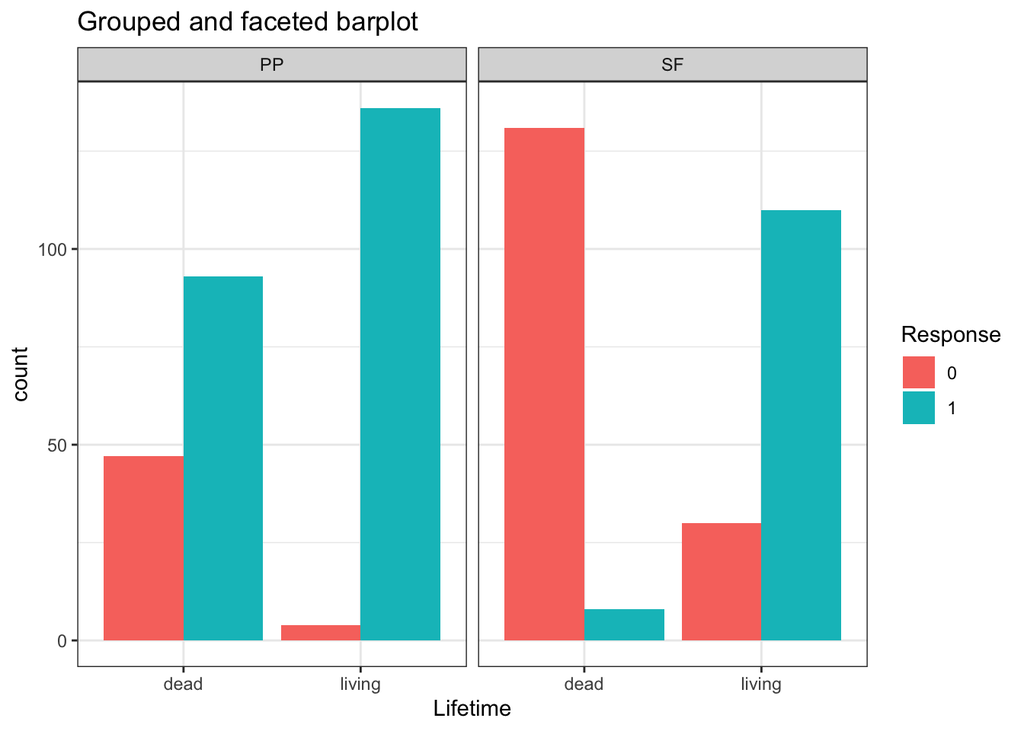

```r
df_lifetime |>
  distinct(px,trial,.keep_all=T) |>
  ggplot(aes(x = lifetime, fill = as.factor(accept))) +
  facet_grid(.~tense) +
  labs(title = "Grouped and faceted barplot",
       x = "Lifetime",
       fill = "Response") +
  geom_bar(position = "dodge") +
  theme_bw()
```

## 8.4 Stacked bar plots

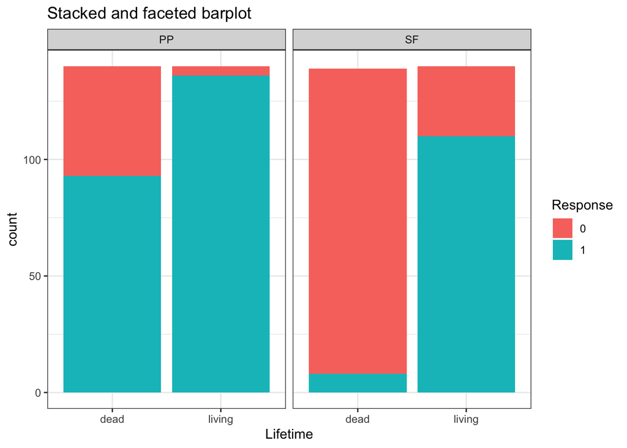

```r
df_lifetime |>
  distinct(px,trial,.keep_all=T) |>
  ggplot(aes(x = lifetime, fill = as.factor(accept))) +
  facet_grid(.~tense) +
  labs(title = "Stacked and faceted barplot",
       x = "Lifetime",
       fill = "Response") +
  geom_bar(position = "stack") +
  theme_bw()
```

### 8.4.1 Exercise

1. Choose the barplot you like best for binary data
2. Reproduce that barplot, but with `reg_in` at the `verb1` region

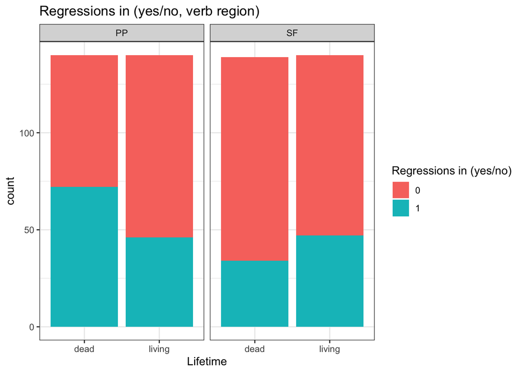

### 8.4.2 Extra exercise

1. Create another bar plot, but for `reg_out` for all sentence regions
2. Use `facet_grid()`
- to have facets by region (columns) and by tense (in 2 rows)

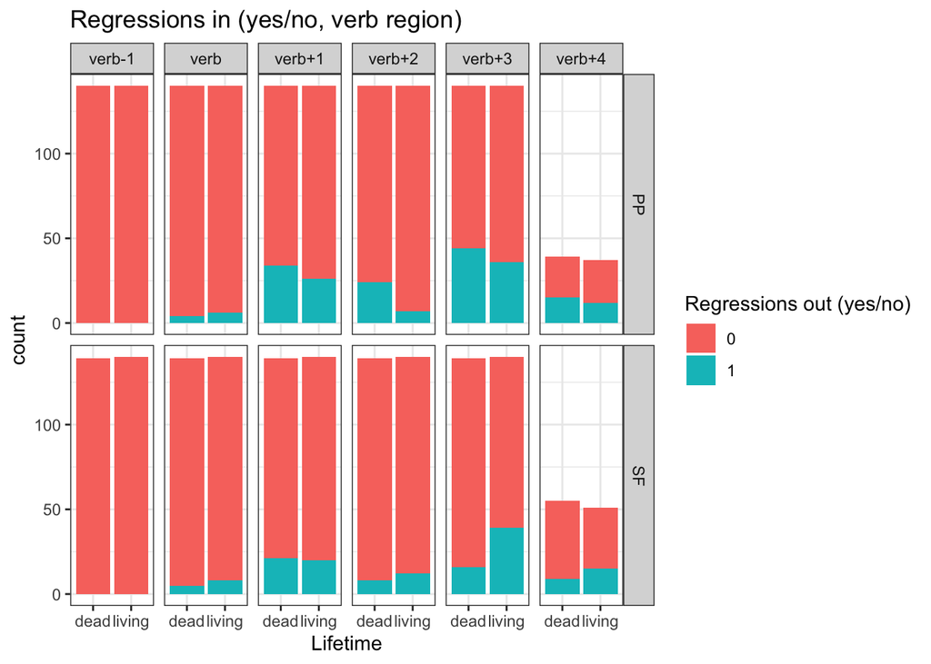

# 9 Resources

Nordmann et al. (2022)

Nordmann & DeBruine (2022)

Wickham et al. (n.d.), [Chapter 2](https://r4ds.hadley.nz/data-visualize.html)

# References

Nordmann, E., & DeBruine, L. (2022). *Applied data skills* (Version 1.0). Zenodo. https://doi.org/10.5281/zenodo.6365078

Nordmann, E., McAleer, P., Toivo, W., Paterson, H., & DeBruine, L. M. (2022). Data Visualization Using R for Researchers Who Do Not Use R. *Advances in Methods and Practices in Psychological Science*, *5*(2), 251524592210746. https://doi.org/10.1177/25152459221074654

Wickham, H., Çetinkaya-Rundel, M., & Grolemund, G. (n.d.). *R for Data Science* (2nd ed.). https://r4ds.hadley.nz/